# Survival Analysis

Chris Troeger

2/23/2022

# Demonstration of survival analysis in R

### Brazilian Nutrition cohort data

```r
library(survival)
library(data.table)
library(RColorBrewer)
library(ggplot2)
library(GGally)
library(parameters)
library(gridExtra)

COLS <- brewer.pal(3, "Set2")

# Setting personal working directory
os <-  "pc"

if(os  == "mac"){
  setwd("~/Documents/OneDrive - UW/PhD/GH Teaching Assistant/Data")
} else {
  setwd("C:/Users/ctroeger/OneDrive - UW/PhD/GH Teaching Assistant/Data/")
}

# Read in data
dt <- fread("Nutrimal_supp.csv")

head(dt)
```

```
##      codigo      sexo age_at_entry faixa_etaria1 socioeconomico
## 1: 1-079-08 masculino         4.10           <=5           rich
## 2: 1-125-09 masculino         4.00           <=5           rich
## 3: 1-112-08 masculino         0.54           <=5           poor
## 4: 1-125-10 masculino         2.50           <=5           rich
## 5: 1-096-07  feminino         2.10           <=5           poor
## 6: 1-064-05 masculino         4.30           <=5         middle
##    malaria-during_fu diagvelocidadecres time_to_first_malaria       HAZ0
## 1:               nao         inadequada                   365 inadequada
## 2:               nao           adequada                   365   adequada
## 3:               nao         inadequada                   365   adequada
## 4:               nao           adequada                   365   adequada
## 5:               nao           adequada                   365   adequada
## 6:               nao         inadequada                   365   adequada
##        WHZ0     WAZ0     BAZ0      HAZ20    WHZ20    WAZ20    BAZ20  HAZ1_aval
```

[output cut: 41 more lines]

The `Surv()` function creates a “survival object” which we will use as the outcome (response) variable in a statistical model. `Surv(time, event)` where `time` is the followup time and `event` is if the event occurs for an observation.

Our data already has this value, time to malaria

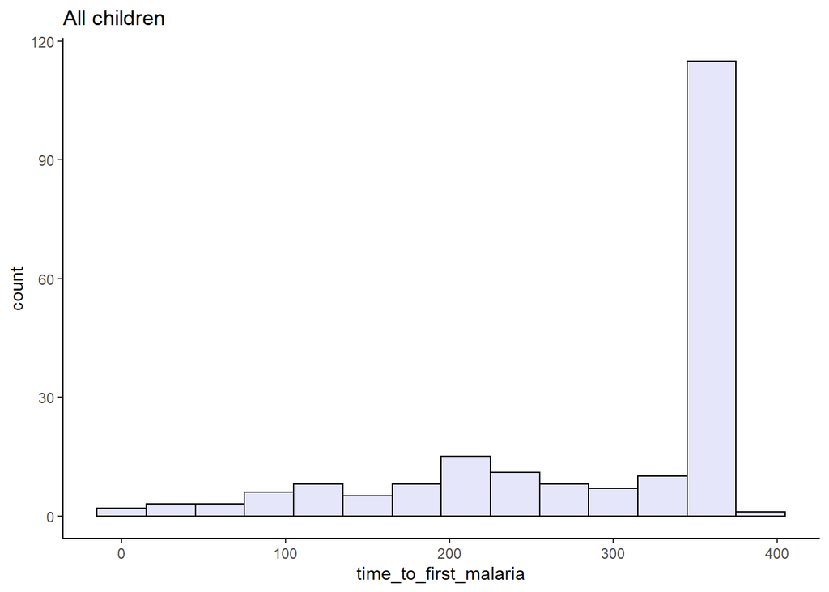

```r
ggplot(dt, aes(x = time_to_first_malaria)) +
  geom_histogram(binwidth = 30, col = "black", fill = "lavender") + theme_classic() + ggtitle("All children")
```

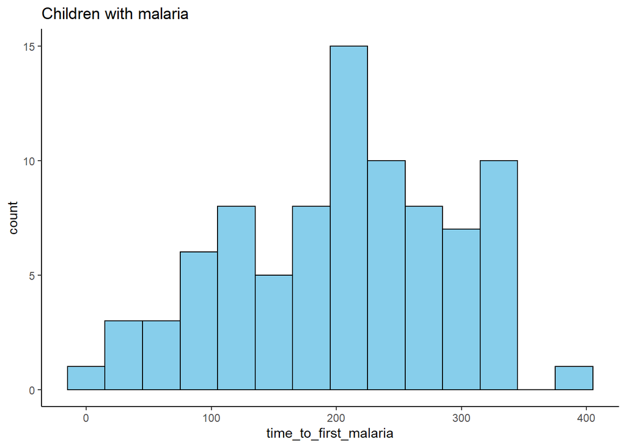

```r
ggplot(dt[malariasn1 == "sim"], aes(x = time_to_first_malaria)) +
  geom_histogram(binwidth = 30, col = "black", fill = "skyblue") + theme_classic() + ggtitle("Children with malaria")
```

Children appear to have malaria throughout the follow up year.

The `survfit()` function creates hazard curves by finding the proportion that has not seen an event at each `time_to_first_malaria` step. I’m going to look at growth trajectory as a predictor of risk of malaria.

I will use `survfit()` to create two lines, one for each growth assessment (adequate/inadequate). This is not a statistical model, it is simply showing the failure rates for each group.

Two ways are shown. The first is the way that Bobby illustrated in class which uses the base R `plot()` function. The second is a function from a ggplot helper package `GGally`.

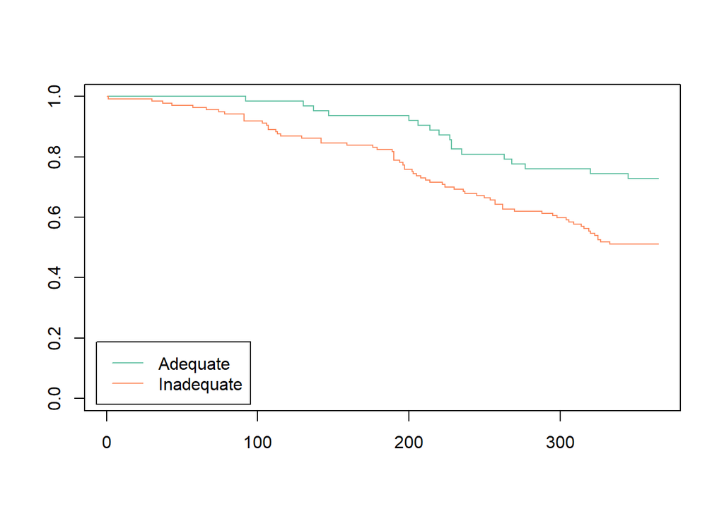

```r
# Survival analysis time_to_first_malaria
# set malaria as the outcome
dt$malaria <- ifelse(dt$malariasn1 == "sim", 1, 0)
dt$anemia_entrance <- ifelse(dt$anemia_entrada == "99", NA,
                             ifelse(dt$anemia_entrada == "sim", 1, 0))
dt <- dt[time_to_first_malaria <= 365]
dt[, growth_trajectory := ifelse(diagvelocidadecres == "adequada",
                                 "Adequate", "Inadequate")]


hcurves <- survfit(Surv(time_to_first_malaria, malaria) ~ growth_trajectory, data = dt)

# plot.survfit() is much more efficient to plot the hazard curves
plot(survfit(Surv(time_to_first_malaria, malaria) ~ growth_trajectory, data = dt),col=COLS[1:2], ylim=c(0, 1))
legend("bottomleft", legend=c("Adequate","Inadequate"), lty=c(1 ,1), inset=0.02,col=COLS[1:2])
```

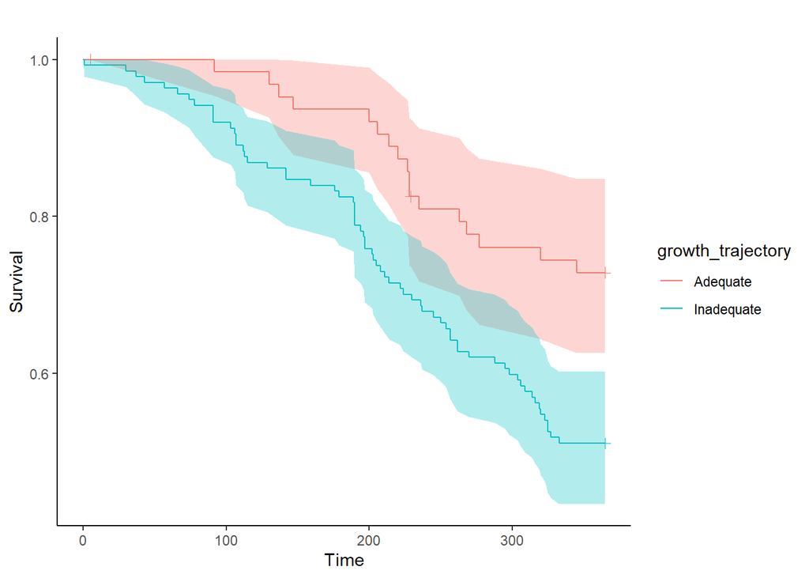

```r
# There is also a ggplot function in the package GGally
ggsurv(hcurves) + geom_ribbon(aes(ymin=low,ymax=up,fill=group),alpha=0.3) +
  theme_classic() + guides(fill = "none")
```

### Cox Proportional Hazards

So we can see that there is an apparent difference in malaria risk by growth trajectory. Let’s use a statistical survival model to see if the difference is statistically significant.

Our function is `coxph()` which will run a Cox proportional hazards model. We use the `Surv()` object as the response in our formula.

```r
cmod <- coxph(Surv(time_to_first_malaria, malaria) ~ growth_trajectory, data = dt)
summary(cmod)
```

```
## Call:
## coxph(formula = Surv(time_to_first_malaria, malaria) ~ growth_trajectory,
##     data = dt)
##
##   n= 201, number of events= 84
##
##                               coef exp(coef) se(coef)     z Pr(>|z|)
## growth_trajectoryInadequate 0.7651    2.1493   0.2717 2.816  0.00486 **
## ---
## Signif. codes:  0 '***' 0.001 '**' 0.01 '*' 0.05 '.' 0.1 ' ' 1
##
##                             exp(coef) exp(-coef) lower .95 upper .95
## growth_trajectoryInadequate     2.149     0.4653     1.262     3.661
##
## Concordance= 0.578  (se = 0.023 )
## Likelihood ratio test= 9.11  on 1 df,   p=0.003
## Wald test            = 7.93  on 1 df,   p=0.005
## Score (logrank) test = 8.32  on 1 df,   p=0.004
```

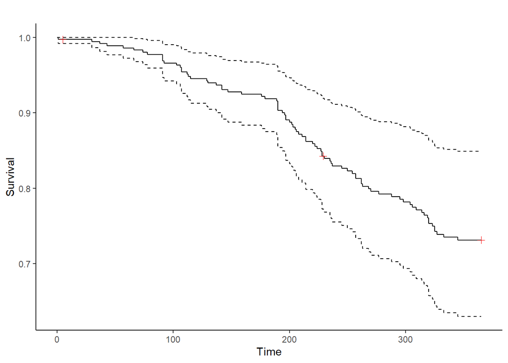

```r
ggsurv(survfit(cmod)) + theme_classic()
```

We can again use `survfit()` to plot our Cox model

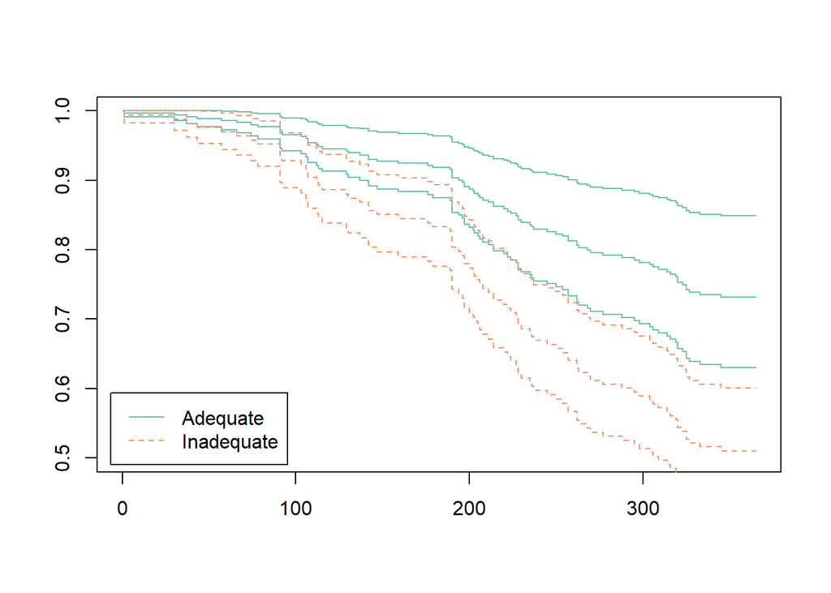

```r
cox_fit <- survfit(cmod, newdata = data.frame(growth_trajectory = c("Adequate", "Inadequate")))

plot(cox_fit,mark=NA,conf.int=TRUE,col=COLS[1:2],lty=c(1,2), ylim = c(0.5,1))
legend("bottomleft", legend=c("Adequate", "Inadequate"), lty=c(1 ,2), inset=0.02,col=COLS[1:2])
```

If we want more control over plotting, we need to understand the survfit objects better.

Let’s start with thinking about what it does with raw data.

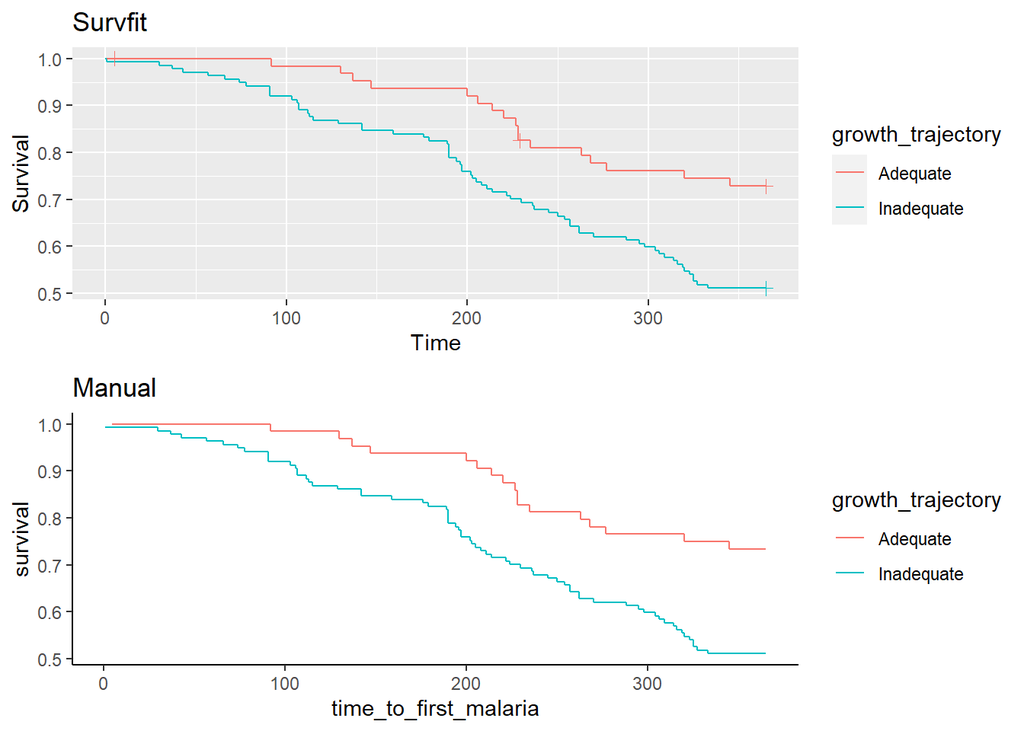

```r
my_data <- dt[, lapply(.SD, function(x) sum(x)),
              .SDcols = c("malaria"),
              by = c("time_to_first_malaria","growth_trajectory")]
n_inadequate <- 137
n_adequate <- 64
my_data[, children := ifelse(growth_trajectory == "Inadequate",
                              n_inadequate, n_adequate)]
my_data <- my_data[order(time_to_first_malaria)]
my_data[, events := cumsum(malaria), by = "growth_trajectory"]
my_data[, survival := 1 - events / children]

a <- ggsurv(hcurves) + ggtitle("Survfit")
b <- ggplot(my_data, aes(x = time_to_first_malaria, y = survival, col = growth_trajectory)) + geom_step() + theme_classic() + ggtitle("Manual")

grid.arrange(a, b)
```

Now, we need to pull information from the `survfit coxph` object. Remember that `survfit` makes hazard curves. It can do this from a `Surv` formula from a `coxph` object.

The returned information is in a list. Let’s investigate that:

```r
View(cox_fit)
```

With this information, I can figure out how to extract the values I am interested int.

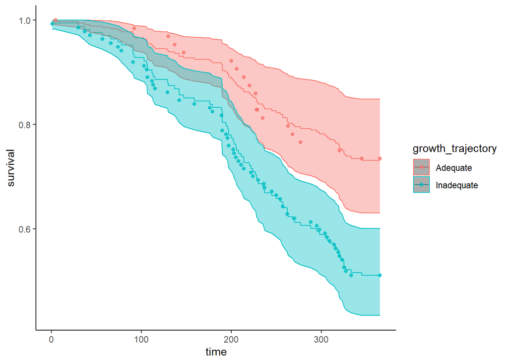

```r
my_estimate <- data.frame(time = rep(cox_fit$time, ncol(cox_fit$surv)),
                      survival = c(cox_fit$surv[,1], cox_fit$surv[,2]),
                      lower = c(cox_fit$lower[,1], cox_fit$lower[,2]),
                      upper = c(cox_fit$upper[,1], cox_fit$upper[,2]),
                      growth_trajectory = c(rep("Adequate", length(cox_fit$time)),
                                            rep("Inadequate", length(cox_fit$time))))

ggplot(my_estimate, aes(x = time, y = survival, col = growth_trajectory)) +
  geom_step() + geom_ribbon(aes(ymin = lower, ymax = upper, fill = growth_trajectory), alpha = 0.4) + guides(fill = "none") +
  geom_point(data = my_data, aes(x = time_to_first_malaria, y = survival,
                                 col = growth_trajectory), alpha = 0.8) +
  theme_classic()
```

Let’s compare with if we used a `glm(family = binomial(link = log))`

```r
gmod <- glm(malaria ~ growth_trajectory, data = dt, family = binomial(link = "log"))

print_md(model_parameters(cmod, exponentiate = T))
```

| Parameter | Coefficient | SE | 95% CI | z | p |
| --- | --- | --- | --- | --- | --- |
| growth trajectory (Inadequate) | 2.15 | 0.58 | (1.26, 3.66) | 2.82 | 0.005 |

```r
print_md(model_parameters(gmod, exponentiate = T))
```

| Parameter | Risk Ratio | SE | 95% CI | z | p |
| --- | --- | --- | --- | --- | --- |
| (Intercept) | 0.27 | 0.06 | (0.17, 0.38) | -6.38 | < .001 |
| growth trajectory (Inadequate) | 1.84 | 0.42 | (1.22, 2.99) | 2.71 | 0.007 |